# Evolution of Running Performances

**Group 26**

**Presented by:** **David Bettane** and **Jeremie Anoufa**

```python
import pandas as pd
import seaborn as sns
import matplotlib.pyplot as plt
import numpy as np
import requests
from IPython.display import Image
from matplotlib.patches import Patch
import matplotlib.patches as mpatches
from matplotlib.lines import Line2D
```

```python
from IPython.display import Image, display
urlpic = "https://archive-share.america.gov/wp-content/uploads/2017/10/shutterstock_548308483_L.jpg"
display(Image(url=urlpic, width=1500))
```

[figure not shown]

https://www.kaggle.com/datasets/jguerreiro/running

The data was scraped from http://www.alltime-athletics.com/index.html

```python
url = 'https://raw.githubusercontent.com/DavidBttne/eda-running-project/refs/heads/main/data.csv'
run_df = pd.read_csv(url)
run_df.head()
```

|  | Rank | Time | Name | Country | Date of Birth | Place | City | Date | Gender | Event |
| --- | --- | --- | --- | --- | --- | --- | --- | --- | --- | --- |
| 0 | 1 | 00:01:40.910000 | David Rudisha | KEN | 1988-12-17 | 1.0 | London | 2012-09-08 | Men | 800 m |
| 1 | 2 | 00:01:41.010000 | David Rudisha | KEN | 1988-12-17 | 1.0 | Rieti | 2010-08-29 | Men | 800 m |
| 2 | 3 | 00:01:41.090000 | David Rudisha | KEN | 1988-12-17 | 1.0 | Berlin | 2010-08-22 | Men | 800 m |
| 3 | 4 | 00:01:41.110000 | Wilson Kipketer | DEN | 1970-12-12 | 1.0 | Köln | 1997-08-24 | Men | 800 m |
| 4 | 5 | 00:01:41.240000 | Wilson Kipketer | DEN | 1970-12-12 | 1.0 | Zürich | 1997-08-13 | Men | 800 m |

```python
run_df.shape
```

```
(18244, 10)
```

```python
run_df.dtypes
```

```
Rank               int64
Time              object
Name              object
Country           object
Date of Birth     object
Place            float64
City              object
Date              object
Gender            object
Event             object
dtype: object
```

```python
run_df.isnull().sum().to_frame('nulls')
```

|  | nulls |
| --- | --- |
| Rank | 0 |
| Time | 0 |
| Name | 0 |
| Country | 0 |
| Date of Birth | 0 |
| Place | 8 |
| City | 0 |
| Date | 0 |
| Gender | 0 |
| Event | 0 |

```python
run_df.columns
```

```
Index(['Rank', 'Time', 'Name', 'Country', 'Date of Birth', 'Place', 'City',
       'Date', 'Gender', 'Event'],
      dtype='object')
```

## 1.Seasonal Influence on Running Performance

```python
run_df['Date']= pd.to_datetime(run_df['Date'])
month_to_saison = {
    12: 'winter', 1: 'winter', 2: 'winter',
    3: 'spring', 4: 'spring', 5: 'spring',
    6: 'summer', 7: 'summer', 8: 'summer',
    9: 'autumn', 10: 'autumn', 11: 'autumn'
}

run_df['Season'] = run_df['Date'].dt.month.map(month_to_saison)
run_df
```

|  | Rank | Time | Name | Country | Date of Birth | Place | City | Date | Gender | Event | Season |
| --- | --- | --- | --- | --- | --- | --- | --- | --- | --- | --- | --- |
| 0 | 1 | 00:01:40.910000 | David Rudisha | KEN | 1988-12-17 | 1.0 | London | 2012-09-08 | Men | 800 m | autumn |
| 1 | 2 | 00:01:41.010000 | David Rudisha | KEN | 1988-12-17 | 1.0 | Rieti | 2010-08-29 | Men | 800 m | summer |
| 2 | 3 | 00:01:41.090000 | David Rudisha | KEN | 1988-12-17 | 1.0 | Berlin | 2010-08-22 | Men | 800 m | summer |
| 3 | 4 | 00:01:41.110000 | Wilson Kipketer | DEN | 1970-12-12 | 1.0 | Köln | 1997-08-24 | Men | 800 m | summer |
| 4 | 5 | 00:01:41.240000 | Wilson Kipketer | DEN | 1970-12-12 | 1.0 | Zürich | 1997-08-13 | Men | 800 m | summer |
| ... | ... | ... | ... | ... | ... | ... | ... | ... | ... | ... | ... |
| 18239 | 1000 | 00:03:33.250000 | Noureddine Morceli | ALG | 1970-02-28 | 1.0 | Moskva | 1995-06-05 | Men | 1500 m | summer |
| 18240 | 1000 | 00:03:33.250000 | Paul Korir | KEN | 1977-07-15 | 5.0 | Zürich | 2003-08-15 | Men | 1500 m | summer |
| 18241 | 1000 | 00:03:33.250000 | Hudson Santos de Souza | BRA | 1977-02-25 | 5.0 | Rieti | 2005-08-28 | Men | 1500 m | summer |
| 18242 | 1000 | 00:03:33.250000 | Issac Songok | KEN | 1984-04-25 | 2.0 | Stockholm | 2006-07-25 | Men | 1500 m | summer |
| 18243 | 1000 | 00:03:33.250000 | Bethwell Birgen | KEN | 1988-08-06 | 7.0 | Lausanne | 2012-08-23 | Men | 1500 m | summer |

18244 rows × 11 columns

```python
run_df['Season'].value_counts()
```

```
Season
summer    9913
spring    3849
autumn    3209
winter    1273
Name: count, dtype: int64
```

```python
run_df["Time_seconds"] = pd.to_timedelta(run_df["Time"]).dt.total_seconds()
```

```python
run_df.groupby(['Event'])['Season'].value_counts().reset_index()
```

|  | Event | Season | count |
| --- | --- | --- | --- |
| 0 | 10,000 m | summer | 944 |
| 1 | 10,000 m | spring | 553 |
| 2 | 10,000 m | autumn | 327 |
| 3 | 10,000 m | winter | 170 |
| 4 | 100 m | summer | 1661 |
| 5 | 100 m | spring | 273 |
| 6 | 100 m | autumn | 229 |
| 7 | 100 m | winter | 4 |
| 8 | 1500 m | summer | 1549 |
| 9 | 1500 m | autumn | 312 |
| 10 | 1500 m | spring | 142 |
| 11 | 1500 m | winter | 3 |
| 12 | 200 m | summer | 1474 |
| 13 | 200 m | spring | 306 |
| 14 | 200 m | autumn | 253 |
| 15 | 200 m | winter | 6 |
| 16 | 400 m | summer | 1302 |
| 17 | 400 m | spring | 355 |
| 18 | 400 m | autumn | 285 |
| 19 | 400 m | winter | 77 |
| 20 | 5000 m | summer | 1305 |
| 21 | 5000 m | spring | 326 |
| 22 | 5000 m | autumn | 236 |
| 23 | 5000 m | winter | 135 |
| 24 | 800 m | summer | 1476 |
| 25 | 800 m | autumn | 229 |
| 26 | 800 m | spring | 221 |
| 27 | 800 m | winter | 77 |
| 28 | Half marathon | spring | 805 |
| 29 | Half marathon | autumn | 633 |
| 30 | Half marathon | winter | 444 |
| 31 | Half marathon | summer | 137 |
| 32 | Marathon | spring | 868 |
| 33 | Marathon | autumn | 705 |
| 34 | Marathon | winter | 357 |
| 35 | Marathon | summer | 65 |

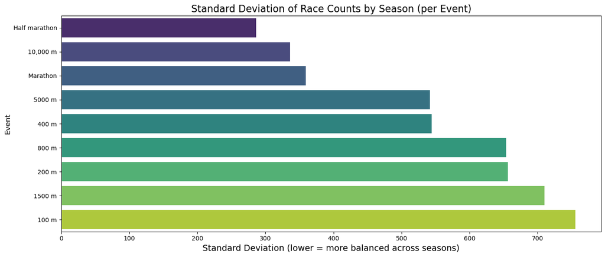

```python
event_season_counts = run_df.groupby(['Event', 'Season'])['Time'].count().unstack(fill_value=0)


event_season_std = event_season_counts.std(axis=1).sort_values(ascending=True)


plt.figure(figsize=(14, 6))
sns.barplot(x=event_season_std.values, y=event_season_std.index, palette='viridis')
plt.title("Standard Deviation of Race Counts by Season (per Event)",fontsize=16)
plt.xlabel("Standard Deviation (lower = more balanced across seasons)",fontsize=14)
plt.ylabel("Event",fontsize=12)
plt.tight_layout()
plt.show()
```

### Because we had a lot of issues with events not being evenly spread across seasons, we made this graph to try and spot which events are actually well represented throughout the year

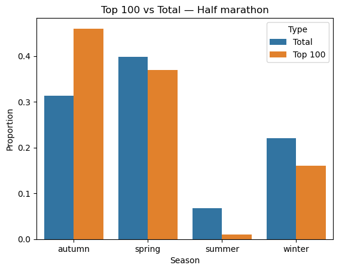

```python
half_total = run_df[run_df['Event'] == 'Half marathon']
top100 = half_total.head(100)

df = pd.DataFrame({
    'Total': half_total['Season'].value_counts(),
    'Top100': top100['Season'].value_counts()
}).fillna(0)

df['Total_prop'] = df['Total'] / df['Total'].sum()
df['Top100_prop'] = df['Top100'] / df['Top100'].sum()

melted = df[['Total_prop', 'Top100_prop']].reset_index().melt(id_vars='Season', var_name='Type', value_name='Proportion')
melted['Type'] = melted['Type'].replace({'Total_prop': 'Total', 'Top100_prop': 'Top 100'})

sns.barplot(data=melted, x='Season', y='Proportion', hue='Type')
plt.title('Top 100 vs Total — Half marathon')
plt.show()
```

### Spring remains stable, while winter suffers from harsher conditions.

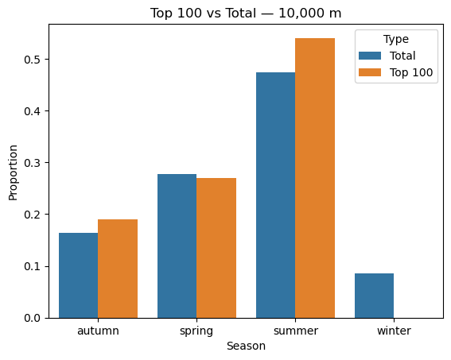

```python
Tenkm=run_df[run_df['Event']=='10,000 m']
top100=Tenkm.head(100)
df = pd.DataFrame({
    'Total': Tenkm['Season'].value_counts(),
    'Top100': top100['Season'].value_counts()
}).fillna(0)

df['Total_prop'] = df['Total'] / df['Total'].sum()
df['Top100_prop'] = df['Top100'] / df['Top100'].sum()

melted = df[['Total_prop', 'Top100_prop']].reset_index().melt(id_vars='Season', var_name='Type', value_name='Proportion')
melted['Type'] = melted['Type'].replace({'Total_prop': 'Total', 'Top100_prop': 'Top 100'})

sns.barplot(data=melted, x='Season', y='Proportion', hue='Type')
plt.title('Top 100 vs Total — 10,000 m')
plt.show()
```

### Unlike the half marathon, summer dominates both participation and Top 100 results in the 10,000 m. This likely reflects a busy summer race calendar and the fact that heat impacts semi-short distances less. Winter is almost absent due to fewer races and tough weather.

## To sum up:

### After analyzing the data, we can say that season and by extension, weather does have an impact on running performance, depending on the type of event. However, we should be cautious: since competitions are not evenly spread throughout the year, our results may reflect participation trends more than pure physical performance.

## 2.Gender-Based Performance Comparison Over the Years

```python
run_df['Year']=run_df['Date'].dt.year
run_df['Year'].value_counts()
```

```
Year
2015    1032
2016    1029
2012     964
2011     791
2013     763
2014     756
2008     736
2010     687
2009     666
2006     643
2000     609
2004     601
2005     594
2007     588
```

[output cut: 41 more lines]

```python
df_women = run_df[run_df['Gender'] == 'Women']
count_women = df_women['Year'].value_counts()
valid_years_women = count_women[count_women > 10].index
df_women = df_women[df_women['Year'].isin(valid_years_women)]
```

```python
finalwomen_df = df_women.groupby(['Event', 'Year'])['Time_seconds'].mean().reset_index()
```

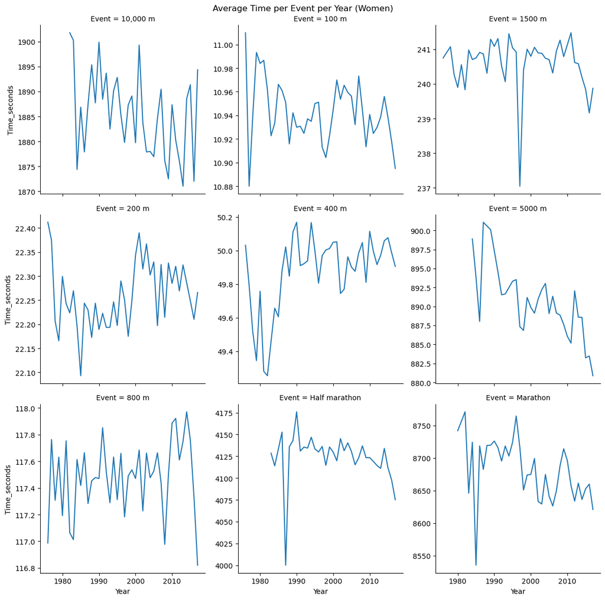

```python
sns.FacetGrid(finalwomen_df, col='Event', col_wrap=3, height=4, sharey=False).map(sns.lineplot, 'Year', 'Time_seconds')
plt.suptitle("Average Time per Event per Year (Women)")
plt.tight_layout()
plt.show()
```

### Conclusion by event and year

```python
df_women['Period'] = (df_women['Year'] // 5) * 5
df_filtered_women = df_women.groupby(['Event', 'Period'])['Time_seconds'].mean().reset_index()
df_filtered_women
```

|  | Event | Period | Time_seconds |
| --- | --- | --- | --- |
| 0 | 10,000 m | 1980 | 1894.160000 |
| 1 | 10,000 m | 1985 | 1888.891132 |
| 2 | 10,000 m | 1990 | 1888.911684 |
| 3 | 10,000 m | 1995 | 1886.632069 |
| 4 | 10,000 m | 2000 | 1882.120443 |
| ... | ... | ... | ... |
| 72 | Marathon | 1995 | 8682.955556 |
| 73 | Marathon | 2000 | 8660.222222 |
| 74 | Marathon | 2005 | 8664.379518 |
| 75 | Marathon | 2010 | 8653.911175 |
| 76 | Marathon | 2015 | 8648.359606 |

77 rows × 3 columns

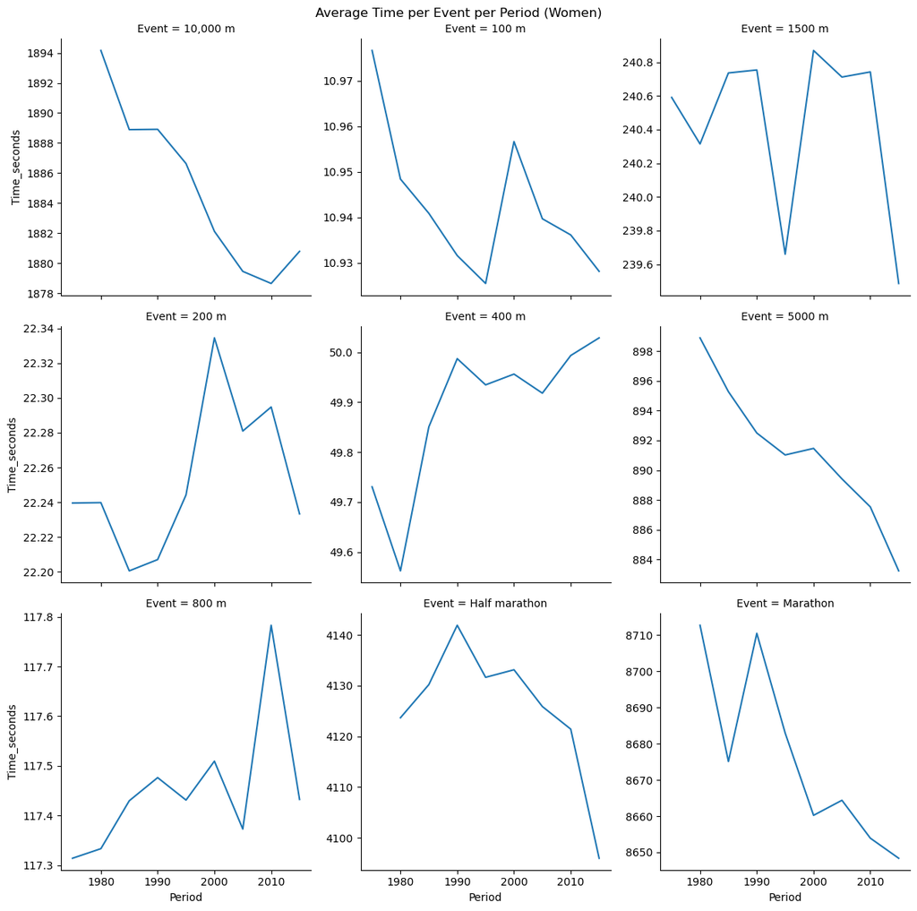

```python
sns.FacetGrid(data=df_filtered_women, col='Event', col_wrap=3, height=4, sharey=False).map(sns.lineplot, 'Period', 'Time_seconds')
plt.suptitle("Average Time per Event per Period (Women)")
plt.tight_layout()
plt.show()
```

```python
df_men=run_df[run_df['Gender']=='Men']
count_men=df_men['Year'].value_counts().index
valid_years=count_men[count_men>10]
valid_years
```

```
Index([2015, 2016, 2012, 2014, 2011, 2013, 2010, 2008, 2009, 2006, 2007, 1996,
       2004, 2000, 1997, 1999, 2005, 1998, 2003, 2001, 2002, 1995, 1992, 1993,
       1988, 2017, 1994, 1991, 1990, 1987, 1989, 1985, 1984, 1986, 1983, 1982,
       1977, 1978, 1980, 1981, 1979, 1968, 1974, 1976, 1975, 1972, 1973, 1971,
       1967, 1962, 1966, 1965, 1969],
      dtype='int32', name='Year')
```

```python
df_men = df_men[df_men['Year'].isin(valid_years)]
```

```python
finalmen_df=df_men.groupby(['Event','Year'])['Time_seconds'].mean().reset_index()
finalmen_df
```

|  | Event | Year | Time_seconds |
| --- | --- | --- | --- |
| 0 | 10,000 m | 1965 | 1659.890000 |
| 1 | 10,000 m | 1972 | 1658.965000 |
| 2 | 10,000 m | 1973 | 1650.800000 |
| 3 | 10,000 m | 1977 | 1655.816000 |
| 4 | 10,000 m | 1978 | 1652.484444 |
| ... | ... | ... | ... |
| 358 | Marathon | 2013 | 7618.211268 |
| 359 | Marathon | 2014 | 7622.898990 |
| 360 | Marathon | 2015 | 7630.802469 |
| 361 | Marathon | 2016 | 7612.694444 |
| 362 | Marathon | 2017 | 7615.025000 |

363 rows × 3 columns

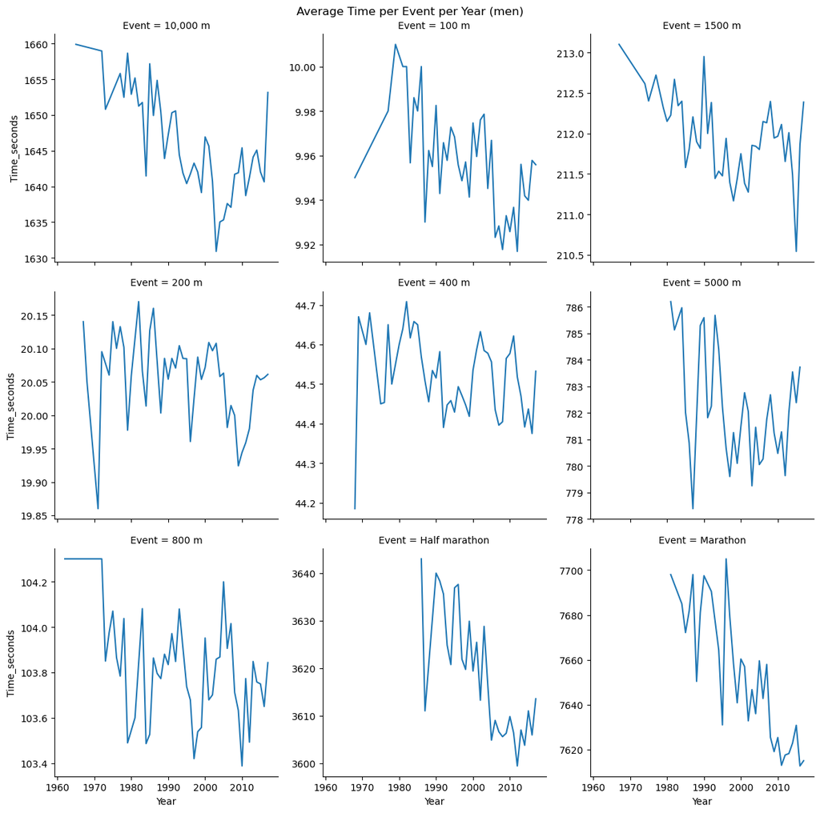

```python
sns.FacetGrid(finalmen_df,col='Event',col_wrap=3,height=4,sharey=False).map(sns.lineplot,'Year','Time_seconds')
plt.suptitle("Average Time per Event per Year (men)")
plt.tight_layout()
plt.show()
```

### In this chart, we observe the evolution of average times over many years, but we’re unable to draw reliable conclusions, since as mentioned earlier the race times are unevenly distributed across the years, here its the main problem.

```python
df_men['Period'] = (df_men['Year'] // 5) * 5
df_filtered=df_men.groupby(['Event','Period'])['Time_seconds'].mean().reset_index()
df_filtered
```

|  | Event | Period | Time_seconds |
| --- | --- | --- | --- |
| 0 | 10,000 m | 1965 | 1659.890000 |
| 1 | 10,000 m | 1970 | 1656.243333 |
| 2 | 10,000 m | 1975 | 1654.552941 |
| 3 | 10,000 m | 1980 | 1651.029412 |
| 4 | 10,000 m | 1985 | 1649.765143 |
| ... | ... | ... | ... |
| 84 | Marathon | 1995 | 7658.677966 |
| 85 | Marathon | 2000 | 7645.190909 |
| 86 | Marathon | 2005 | 7636.283333 |
| 87 | Marathon | 2010 | 7619.178404 |
| 88 | Marathon | 2015 | 7620.777202 |

89 rows × 3 columns

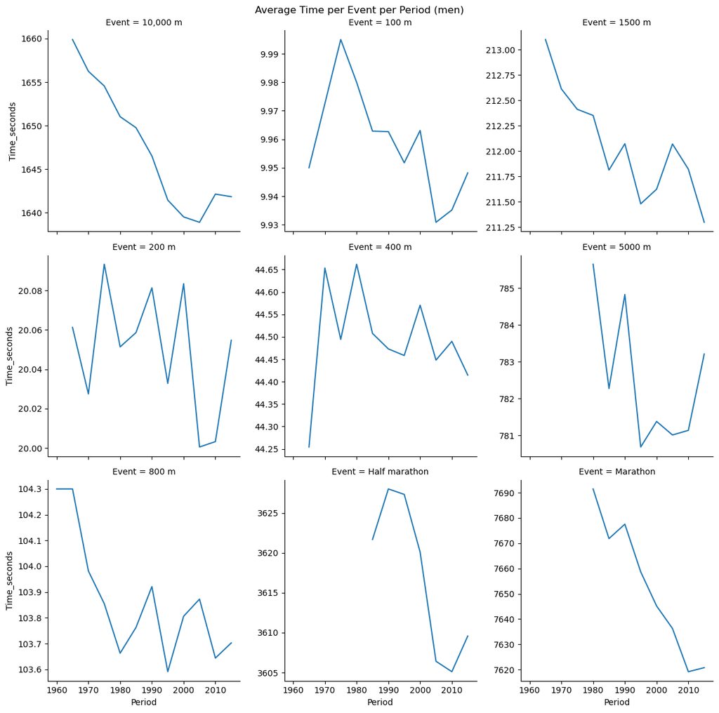

```python
sns.FacetGrid(data=df_filtered, col='Event', col_wrap=3, height=4, sharey=False).map(sns.lineplot, 'Period', 'Time_seconds')
plt.suptitle("Average Time per Event per Period (men)")
plt.tight_layout()
plt.show()
```

### Here, we averaged performances over 5-year periods, which allowed us to identify clearer trends, with an overall decrease in times across most events. However, some inconsistencies remain, particularly in the 200m and the 5000m.

```python
run_df['Period'] = (run_df['Year'] // 5) * 5
```

```python
avg_time = run_df.groupby(['Event', 'Gender', 'Period'])['Time_seconds'].mean().reset_index()
first = avg_time.groupby(['Event', 'Gender']).first().reset_index()
last = avg_time.groupby(['Event', 'Gender']).last().reset_index()
first['Delta'] = first['Time_seconds'] - last['Time_seconds']
final_df = first[['Event', 'Gender', 'Delta']]
```

[output not shown]

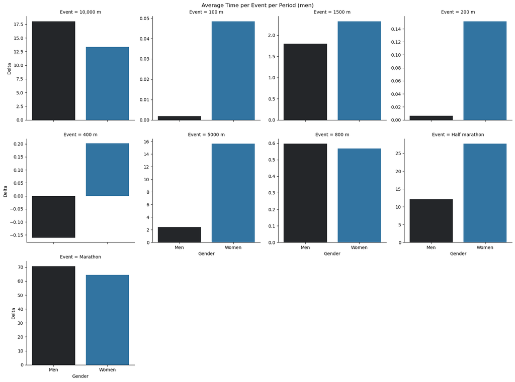

```python
sns.FacetGrid(final_df, col='Event', col_wrap=4, height=4, sharey=False).map_dataframe(sns.barplot,x='Gender',y= 'Delta', hue= 'Gender')
plt.suptitle("Average Time per Event per Period (men)")
plt.tight_layout()
plt.show()
```

## 3.The Impact of Age on Athletic Performance

```python
run_df['Date'] = pd.to_datetime(run_df['Date'])
run_df['Date of Birth'] = pd.to_datetime(run_df['Date of Birth'])
run_df['Age'] = (run_df['Date'] -run_df['Date of Birth']).dt.days // 365
```

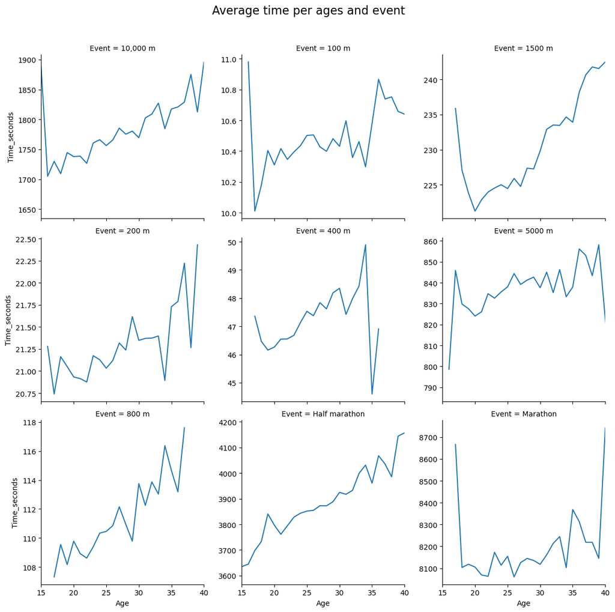

```python
df_grouped = run_df.groupby(['Event', 'Age'])['Time_seconds'].mean().reset_index()
graph=sns.FacetGrid(df_grouped, col='Event', col_wrap=3, height=4, sharey=False).map_dataframe(sns.lineplot, x='Age', y='Time_seconds')
graph.set(xlim=(15,40))
plt.suptitle("Average time per ages and event", fontsize=16)
plt.subplots_adjust(top=0.90)
```

### Overall, these graphs reveal a clear trend: a decline in speed is associated with increasing age.

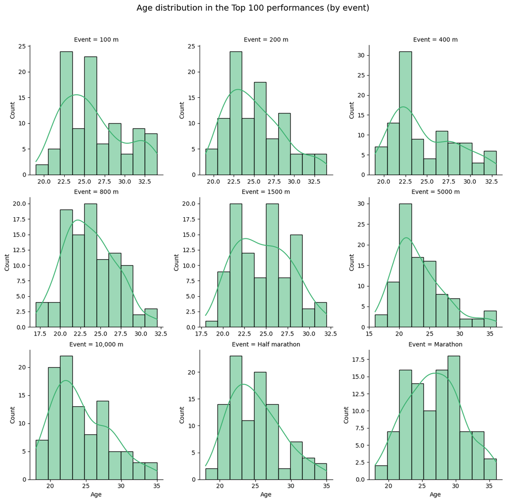

```python
top100 = ( run_df.sort_values(by='Time_seconds').groupby('Event').head(100))
sns.FacetGrid(top100, col="Event", col_wrap=3, height=4, sharex=False, sharey=False).map(sns.histplot, "Age", kde=True, bins=10, color="mediumseagreen").fig.suptitle("Age distribution in the Top 100 performances (by event)", fontsize=14)
plt.subplots_adjust(top=0.90)
plt.show()
```

```python
top10 = run_df.sort_values(by='Time_seconds').groupby('Event').head(10)
median_age_top10 = top10.groupby('Event')['Age'].median().reset_index(name='Age_top10')

top1 = run_df.sort_values(by='Time_seconds').groupby('Event').head(1)
record_age = top1[['Event', 'Age']].rename(columns={'Age': 'Age_record'})
```

```python
df_lollipop = record_age.merge(median_age_top10, on='Event')
```

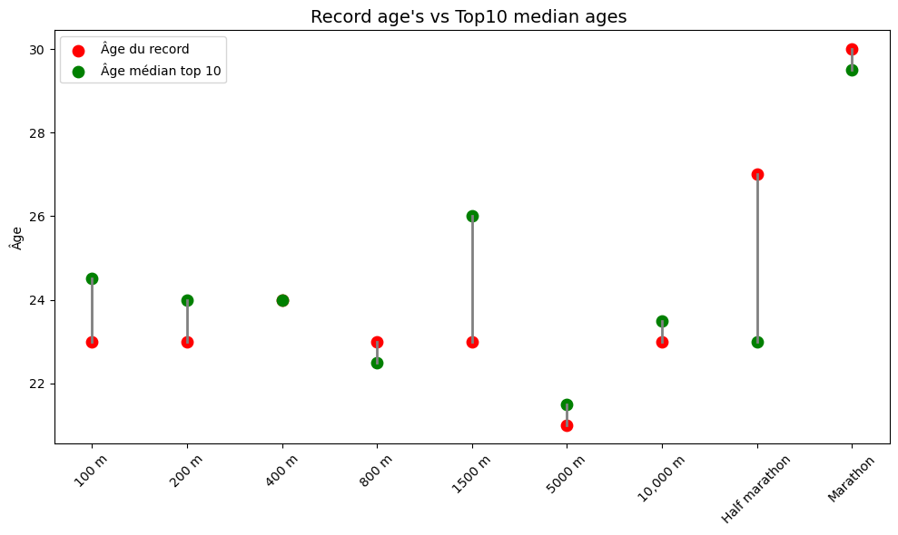

```python
plt.figure(figsize=(10, 6))
for i, row in df_lollipop.iterrows():
    plt.plot([i, i], [row['Age_record'], row['Age_top10']], color='gray', lw=2)
    plt.scatter(i, row['Age_record'], color='red', s=80, label='Âge du record' if i == 0 else "")
    plt.scatter(i, row['Age_top10'], color='green', s=80, label='Âge médian top 10' if i == 0 else "")
plt.xticks(range(len(df_lollipop)), df_lollipop['Event'], rotation=45)
plt.ylabel("Âge")
plt.title("Record age's vs Top10 median ages ", fontsize=14)
plt.legend()
plt.tight_layout()
plt.show()
```

### The lollipop chart clearly shows that younger athletes (mostly between 22 and 25 years old) dominate the majority of events, especially in sprints and middle-distance races.However, in longer-distance events such as the half-marathon and marathon, this trend shifts.Older athletes remain highly competitive, sometimes even holding the best performances.

# Conclusion

## While age clearly shapes athletic performance, its impact varies by event type.In sprints and middle distances, athletes typically peak between 22 and 25, when speed and power are at their maximum.

## However, in long-distance events like the half-marathon and marathon, older athletes remain highly competitive.

## This reflects real-world dynamics: while speed declines with age, endurance and efficiency can improve over time, supported by years of training and race experience.